# POLI 572B

Michael Weaver

February 25, 2019

# Plan for Today

### Review

1. Questions on PS 4

### Least Squares and Causality

1. Review Least Squares
   - algorithm
   - statistical inference
2. A causal model for regression
3. Omitted Variable Bias
4. Conditioning
5. Regression and Conditioning

# Questions

# Questions on Problem Set 4

# Questions on Least Squares and Statistical Inference

# Least Squares Review

# Least Squares: Algorithm

- Least Squares can model the mean of a variable $Y$ as a linear function of some other variable (bivariate) or mean of a variable $Y$ as a linear function of several other variables (multivariate)
- The fitted values of $Y$ are chosen to have the smallest distance to the true values of $Y$, and so the residuals are orthogonal to the variables in $X$.
- To do this, we just need to have $n > p$ and matrix $X$ must be invertable

# Least Squares: Statistical Inference

We can also, making assumptions, use regression to estimate, with uncertainty the true value of slope coefficient.

- If the model $Y = \beta X + \epsilon$ where the slopes in $\beta$ are constant and additive for all cases is correct
- If the $\epsilon_i$ are independent and indentically distributed, with mean 0
- If $\epsilon_i$ is **independent** of $X_i$: $X \mathrel{\unicode{x2AEB}} \epsilon$

Then, $\hat{\beta}$ is **unbiased** and has a known sampling distribution that we can estimate from the data.

# Least Squares

Nothing so far on how regression relates to **causality**

To understand link to causality

- Need to imagine a **causal model** for regression (to parallel the Neyman Causal Model)
- What are sources of bias?
- Connection between regression and conditioning

# A Causal Model for Least Squares

# Response Schedule

In the context of **experiments**, we imagined that each observation has potential outcomes corresponding to their behavior under different treatments

- To find the average causal effect of treatment without bias, we had to assume that only treatment status affects the outcome and that treatment is assigned in a manner unrelated to potential outcomes

# Response Schedule

In regression, where levels of treatment might be continuous, we generalize this idea to the “response schedule”:

- some equation that reflects potential outcomes across different values of the “treatment”

$$Y^X_i = \alpha + \beta X + \epsilon_i$$
Here $Y_i^X$ is the potential outcome for $i$ for a value of $X$.

- this response schedule says that $Y_i$ changes same amount for all unit changes in $X$.
- We only ever observe one $Y_i^X$ for the value of $X$ that is given, others are counterfactual.

# Response Schedule

If we don’t know parameters $\alpha, \beta$, what do we need to assume to obtain an estimate $\widehat{\beta}$ that we can give a **causal** interpretation? (Unit change in $X$ **causes** $\widehat{\beta}$ change in $Y$)

**We must assume**

- $Y_i$ actually produced according to the response schedule (equation is correctly specified; e.g., linear and additive)
- $X_i$ is chosen at random, so independent of $\epsilon_i$: $X_i \mathrel{\unicode{x2AEB}} \epsilon_i$. Sometimes we say $X$ is **exogenous**

# How does this go wrong?

If the true process generating the data is:

$$Y_i = \beta_0 + \beta_1 X_i + \beta_2 Z_i + \epsilon_i$$

with $(X_i,Z_i) \mathrel{\unicode{x2AEB}} \epsilon_i$, $E(\epsilon_i) = 0$, $Var(\epsilon_i) = \sigma^2$

What happens when we regress $Y_i$ on a constant and $X_i$ and exclude $Z_i$?

Because this is a bivariate regression ($Y = \widehat{\beta_0} + \widehat{\beta_1} X_i + e_i$)

$$\small\begin{eqnarray}
\widehat{\beta_1} &=& \frac{Cov(X_i, Y_i)}{Var(X_i)} \\
&=& \frac{Cov(X_i, \beta_0 + \beta_1 X_i + \beta_2 Z_i + \epsilon_i)}{Var(X_i)} \\
&=& \frac{Cov(X_i, \beta_1 X_i)}{Var(X_i)} + \frac{Cov(X_i,\beta_2 Z_i)}{Var(X_i)} + \frac{Cov(X_i,\epsilon_i)}{Var(X_i)} \\
&=& \beta_1\frac{Var(X_i)}{Var(X_i)} + \beta_2\frac{Cov(X_i, Z_i)}{Var(X_i)} \\
&=& \beta_1 + \beta_2\frac{Cov(X_i, Z_i)}{Var(X_i)}
\end{eqnarray}$$

So, $E(\widehat{\beta_1}) \neq \beta_1$, it is **biased**

# Omitted Variable Bias

### This bias is **omitted variable bias**

# Omitted Variable Bias

If the truth is: $Y_i = \beta_0 + \beta_1 X_i + \beta_2 Z_i + \epsilon_i$

And $\widehat{\beta_1} = \beta_1 + \beta_2\frac{Cov(X_i, Z_i)}{Var(X_i)}$

What is the direction of the bias when:

1. $\beta_2$ is positive; $\frac{Cov(X_i, Z_i)}{Var(X_i)} < 0$
2. $\beta_2$ is negative; $\frac{Cov(X_i, Z_i)}{Var(X_i)} < 0$
3. $\beta_2$ is positive; $\frac{Cov(X_i, Z_i)}{Var(X_i)} > 0$
4. $\beta_2$ is $0$; $\frac{Cov(X_i, Z_i)}{Var(X_i)} > 0$

# Omitted Variable Bias

This is only source of bias if two things are true:

1. $\beta_2 \neq 0$: omitted variable $Z$ has (or is correlated with something that has) an effect on $Y$
2. $\frac{Cov(X_i, Z_i)}{Var(X_i)} \neq 0$: omitted variable $Z$ is correlated with $X$.

This is why we don’t need to include EVERYTHING that might affect $Y$ in our regression equation.

# Conditioning

# OVB: visually

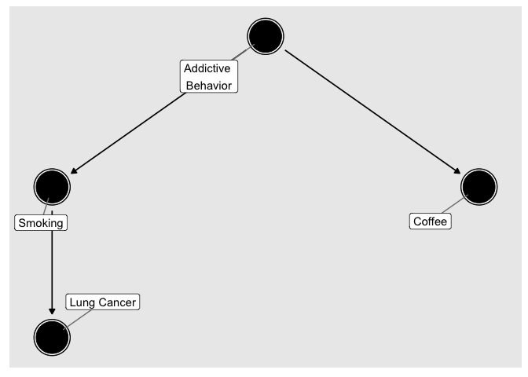

# OVB: visually

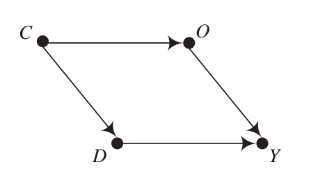

# Conditioning

**conditioning** is when we examine the effect of $X_i$ on $Y_i$ within subsets/strata of the data defined by the values of $Z_i$, **blocking** backdoor (non causal) paths from $X$ to $Y$.

# Conditioning

We may be tempted to condition on as many variables as possible, but this can lead to trouble!

**colliders**: variable that is causally influenced by two or more variables. The causal variables influencing the collider are themselves not necessarily associated.

- conditioning on the collider can INDUCE associations between variables that were not associated.

# Conditioning

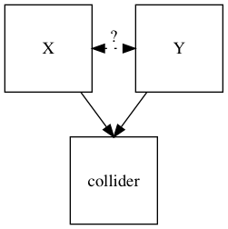

# Conditioning

Consider Graduate School Admissions:

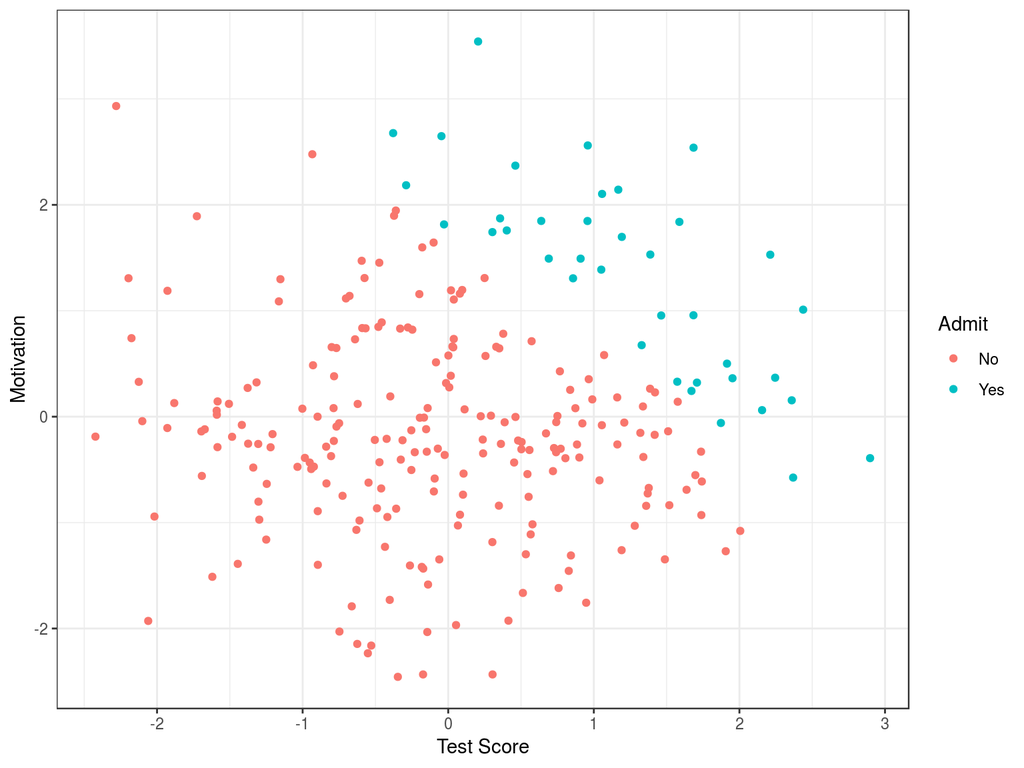

# Conditioning

If both **motivation** and **test scores** cause admission (but are independent of each other), conditioning on admission (stratifying by admission) can lead us to see negative association between the two.

When does this arise?

- Can happen in a variety of circumstances, but is VERY COMMON for variables that are “post-treatment” (let’s draw this)
- See Morgan and Winship, Chapter 4

# Conditioning

- Do not condition on “post-treatment” variables
- Condition on variables that affect “treatment” assignment

# Conditioning: Example

Imagine we have a binary treatment $X_i$ and we want to know its average effect on $Y_i$.

But we lack random assignment; $Z_i$ affects $Y_i$ and is associated with $X_i$.

What do we do? Condition

Example (1)

|  | $Y_i^1$ | $Y_i^0$ | $X_i$ | $Z_i$ | $Y_i$ | $\tau_i$ |
| --- | --- | --- | --- | --- | --- | --- |
| treated | 20 | 10 | 1 | 1 | 20 | 10 |
| treated | 20 | 10 | 1 | 1 | 20 | 10 |
| treated | 15 | 5 | 1 | 0 | 15 | 10 |
| untreated | 20 | 10 | 0 | 1 | 10 | 10 |
| untreated | 15 | 5 | 0 | 0 | 5 | 10 |
| untreated | 15 | 5 | 0 | 0 | 5 | 10 |

```r
ace = mean(c(10,10,10,10,10,10))
ace_hat = mean(c(20,20,15)) - mean(c(10,5,5))
ace
```

```
## [1] 10
```

```r
ace_hat
```

```
## [1] 11.66667
```

Why isn’t $\widehat{ACE} = ACE$?

In this case, **conditioning** would be to find the effect of $X_i$ on $Y_i$ within subsets of the data defined by the values of $Z_i$. Rather than taking the difference:

$\bar{Y^1} - \bar{Y^0} = (\bar{Y} | X = 1) - (\bar{Y}| X = 0)$

We calculate:

$(\bar{Y^1} - \bar{Y^0} | Z = z)$ for each value of $z$ in the data.

Example (1): Let’s “condition” on $Z$

|  | $Y_i^1$ | $Y_i^0$ | $X_i$ | $Z_i$ | $Y_i$ | $\tau_i$ |
| --- | --- | --- | --- | --- | --- | --- |
| treated | 20 | 10 | 1 | 1 | 20 | 10 |
| treated | 20 | 10 | 1 | 1 | 20 | 10 |
| untreated | 20 | 10 | 0 | 1 | 10 | 10 |
| treated | 15 | 5 | 1 | 0 | 15 | 10 |
| untreated | 15 | 5 | 0 | 0 | 5 | 10 |
| untreated | 15 | 5 | 0 | 0 | 5 | 10 |

```r
ace_z0 = mean(c(15)) - mean(c(5,5))
ace_z1 = mean(c(20,20)) - mean(c(10))
mean(c(ace_z0, ace_z1))
```

```
## [1] 10
```

Why does “conditioning” recover the true ACE in this case?

Example (2)

|  | $Y_i^1$ | $Y_i^0$ | $X_i$ | $Z_i$ | $Y_i$ | $\tau_i$ |
| --- | --- | --- | --- | --- | --- | --- |
| treated | 20 | 10 | 1 | 1 | 20 | 10 |
| treated | 20 | 10 | 1 | 1 | 20 | 10 |
| treated | 15 | 5 | 1 | 0 | 15 | 10 |
| untreated | 18 | 10 | 0 | 1 | 10 | 8 |
| untreated | 15 | 5 | 0 | 0 | 5 | 10 |
| untreated | 15 | 5 | 0 | 0 | 5 | 10 |

```r
ace = mean(c(10,10,10,10,10,8))
ace
```

```
## [1] 9.666667
```

```r
ace_hat = mean(c(20,20,15)) - mean(c(10,5,5))
ace_hat
```

```
## [1] 11.66667
```

Why isn’t $\widehat{ACE} = ACE$?

Example (2): Let’s “condition” on $Z$

|  | $Y_i^1$ | $Y_i^0$ | $X_i$ | $Z_i$ | $Y_i$ | $\tau_i$ |
| --- | --- | --- | --- | --- | --- | --- |
| treated | 20 | 10 | 1 | 1 | 20 | 10 |
| treated | 20 | 10 | 1 | 1 | 20 | 10 |
| untreated | 18 | 10 | 0 | 1 | 10 | 8 |
| treated | 15 | 5 | 1 | 0 | 15 | 10 |
| untreated | 15 | 5 | 0 | 0 | 5 | 10 |
| untreated | 15 | 5 | 0 | 0 | 5 | 10 |

```r
ace_z0 = mean(c(15)) - mean(c(5,5))
ace_z1 = mean(c(20,20)) - mean(c(10))
mean(c(ace_z0, ace_z1))
```

```
## [1] 10
```

- Has conditioning uncovered the true ATE?
- Why not?
- Effect of treatment is correlated with treatment status

# Conditioning: Example

This can also be expressed in terms of our regression model:

$Y_i = \alpha + \tau \cdot X_i + \beta \cdot Z_i + \epsilon_i$

In this case, because $X_i$ is binary, we can decompose $\epsilon_i$ into:

$\epsilon_i = \nu_i^0 + X_i \cdot (\nu_i^1 - \nu_i^0)$

Where:

$\nu_i^0 = Y_i^0 - \bar{Y^0}$ (the residual for $i$ from the mean $Y$ without treatment)

$\nu_i^1 = Y_i^1 - \bar{Y^1}$ (the residual for $i$ from the mean $Y$ with treatment)

[output not shown]

- $\epsilon_i$ is not independent of $X_i$, after conditioning on values of $Z_i$. It is larger when $X_i = 1$.

# Conditioning With Regression

# Conditioning with Regression

- There are multiple ways to condition (matching, inverse probability weighting, regression)
- Regression has certain advantages
  - good linear approximation
  - (sometimes) fairly easy to understand
  - used a lot
- But conditioning with regression can lead us into trouble

# Potential Pitfalls

### (1) Omitted Variable Bias

- Excluding some variable $Z$ that should be in the model
- Induces bias if $Z$ is causally related to both $X$ and $Y$
- How do we know whether there is some missing $Z$ we need to include?
- We need to make a big assumption that we’ve included all relevant confounding variables: **conditional independence assumption** or **ignorability**

# Potential Pitfalls

Even if we included all variables, we could have problems due to simplifications of our model:

- we typically assume the model is linear and additive.
- but the world might be non-linear and interactive (effect of $X$ on $Y$ depends on $Z$)
- our decisions about how to specify the math of regression equation can lead to bias

# Potential Pitfalls

### (2) Interpolation Bias:

- By forcing relationship between $Z$ (and for generality $Z_1 \ldots Z_k$) and $X$ to be linear and additive, conditioning on $Z$ may not fully remove association between $Z$ and $X$, $Z$ and $Y$.
- This unmodeled relationship will become part of $\epsilon$, and will not be independent of $X$.
- We don’t look at strata defined by sharing exactly the same attributes, we approximate linearly. If linear approximation is wrong, we have bias.

# Example: Interpolation

# Example: Interpolation

We can examine lawyers and doctors in the American Community Survey.

- Does working more hours increase earnings?
- It is likely that age is associated with hours worked and to earnings
- Omitting age could lead to OVB

# Example: Interpolation

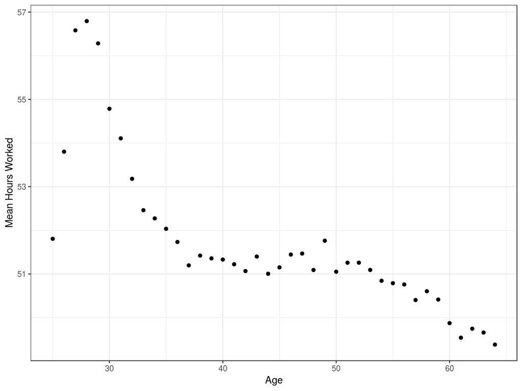

# Example: Interpolation

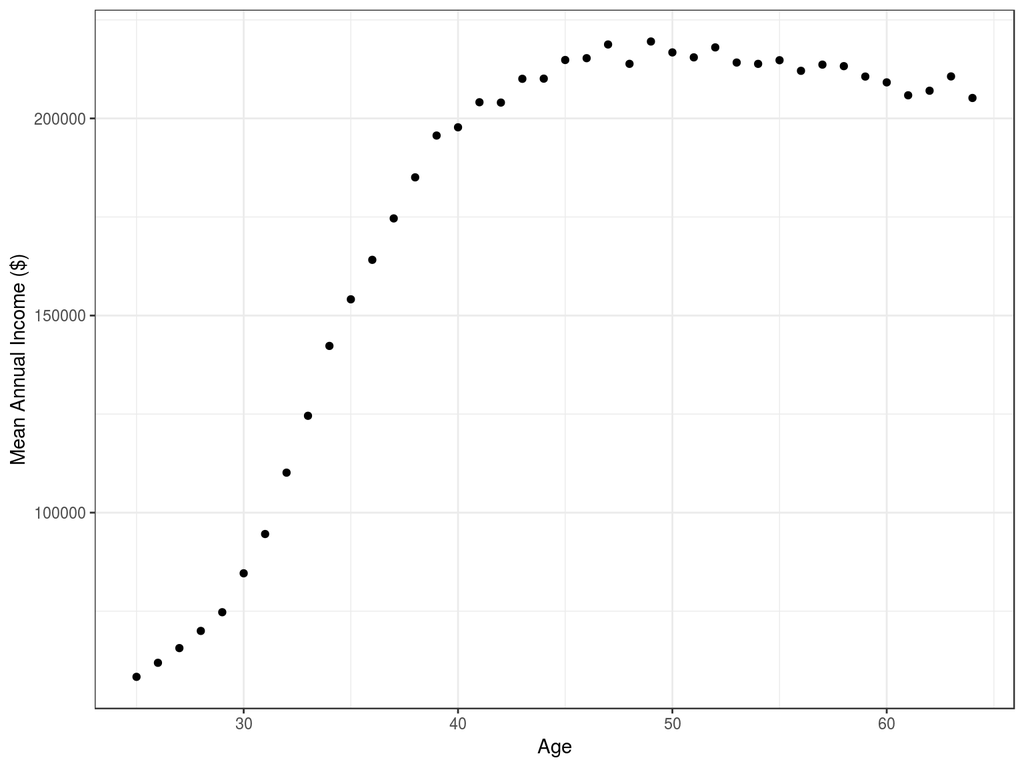

# Example: Interpolation

To condition on age, we can regress income on hours worked and age:

```r
lm_hours_age = lm(INCEARN ~ UHRSWORK + AGE, acs_data)
summary(lm_hours_age)$coefficients
```

```
##               Estimate Std. Error   t value Pr(>|t|)
## (Intercept) -94984.969 2100.02853 -45.23032        0
## UHRSWORK      2048.503   27.17378  75.38531        0
## AGE           3822.714   30.53602 125.18705        0
```

# After Conditioning…

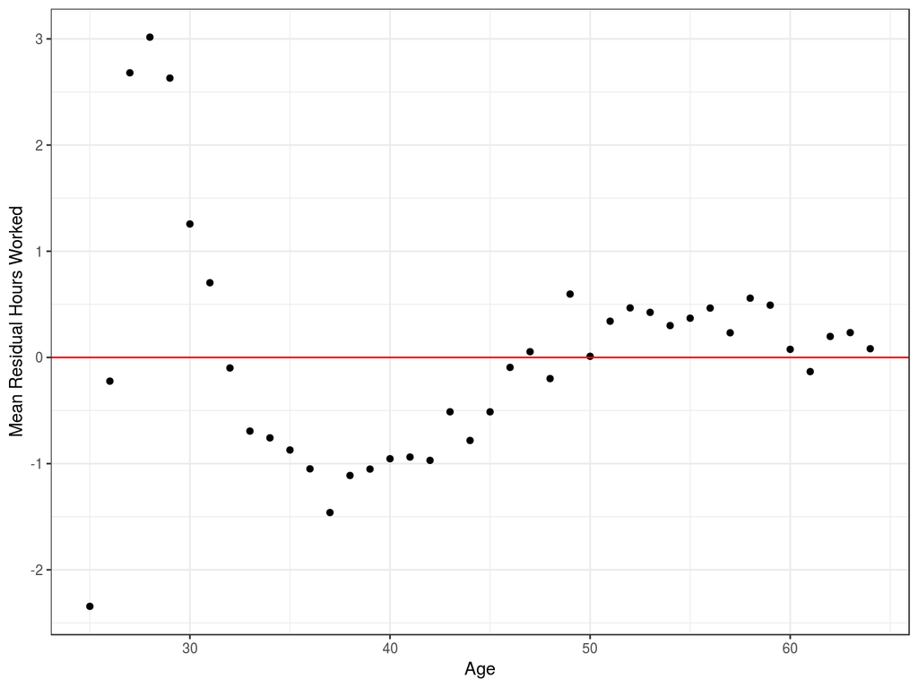

# After Conditioning…

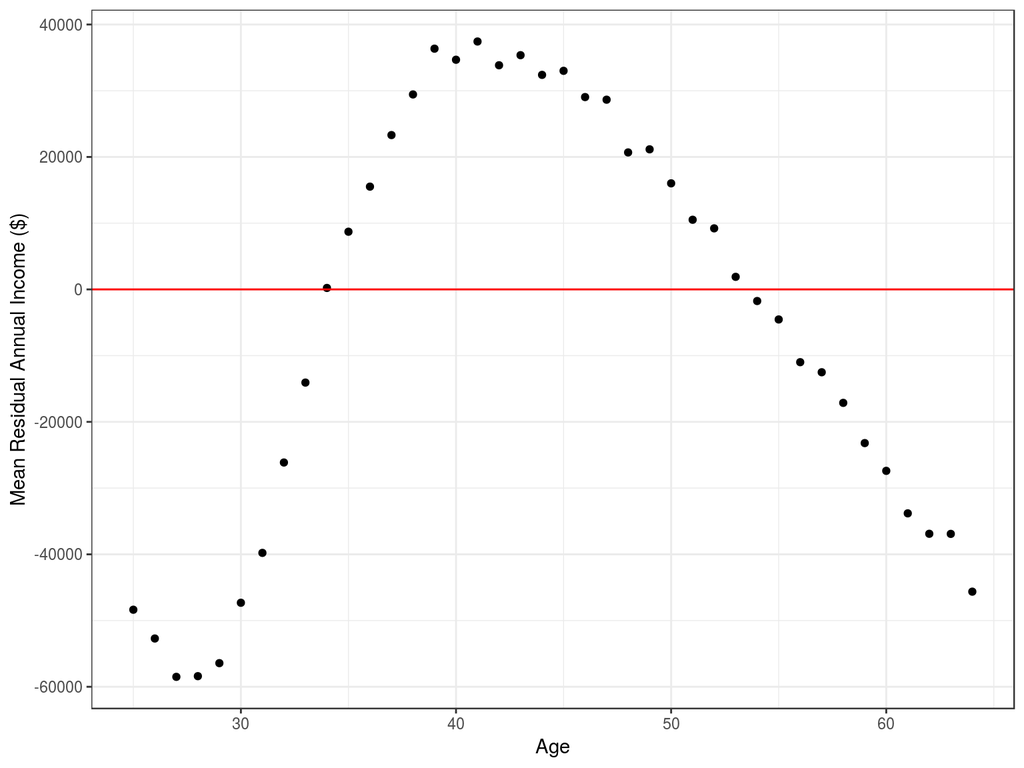

# Interpolation Bias

Age is still related to hours worked and income, just non-linearly

- this will induce omitted variable bias (but its form will be non-linear)

# Interpolation Bias

Errors not independent of Hours Worked

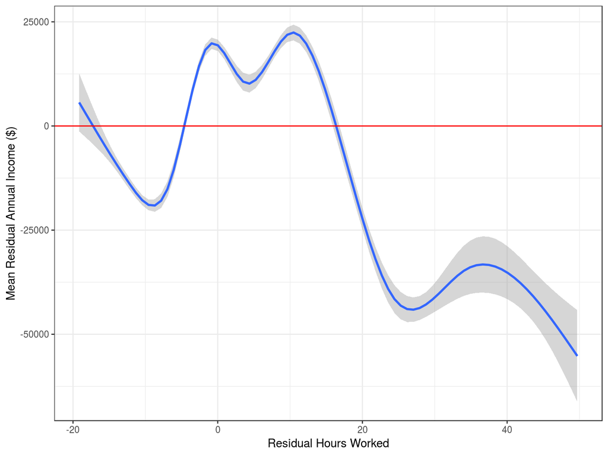

# Interpolation Bias

What can we do?: We can model relationship between $Z$ and $X,Y$ more flexibly.

In the extreme we can **saturate** the model in terms of $Z$: fit a dummy variable for each unique value of $Z$.

- if $Z$ contains multiple variables, then a dummy for each unique set of a values
- If we do this, then regression does conditioning that stratifies exactly on $Z$, as we did in exercise
- Regression returns a **weighted** average of effects of $X$ across all strata defined by $Z$.
- This average is weighted by **variance** (more weight placed on strata with greater residual variance in $X$)

*n.b.*: also be careful about interpolation assumptions about $X$. We are treating every one unit increase in $X$ has having the same effect (may not be reasonable)

# Interpolation Bias

```r
lm_hour_age_sat = lm(INCEARN ~ UHRSWORK + as.factor(AGE), acs_data)
summary(lm_hour_age_sat)$coefficients
```

```
##                     Estimate Std. Error     t value      Pr(>|t|)
## (Intercept)      -55171.9147 7467.87661 -7.38789853  1.498592e-13
## UHRSWORK           2191.1319   26.55789 82.50397680  0.000000e+00
## as.factor(AGE)26   -807.3248 8259.75793 -0.09774194  9.221373e-01
## as.factor(AGE)27  -3171.8371 7796.49275 -0.40682871  6.841343e-01
## as.factor(AGE)28    725.1805 7665.06078  0.09460858  9.246259e-01
## as.factor(AGE)29   6586.1605 7617.69858  0.86458665  3.872669e-01
## as.factor(AGE)30  19741.2277 7589.93240  2.60097543  9.296732e-03
## as.factor(AGE)31  31190.4601 7587.68446  4.11066911  3.947027e-05
## as.factor(AGE)32  48792.0034 7573.62502  6.44235795  1.179500e-10
## as.factor(AGE)33  64787.0808 7575.76442  8.55188694  1.220933e-17
## as.factor(AGE)34  82924.2810 7575.35015 10.94659381  7.051884e-28
## as.factor(AGE)35  95271.4492 7569.53430 12.58617048  2.613457e-36
## as.factor(AGE)36 105944.6423 7577.94253 13.98066055  2.167533e-44
## as.factor(AGE)37 117629.2020 7571.19304 15.53641565  2.147648e-54
## as.factor(AGE)38 127553.6691 7571.23135 16.84714984  1.243109e-63
## as.factor(AGE)39 138298.9322 7579.87592 18.24554038  2.652768e-74
## as.factor(AGE)40 140451.3894 7571.18629 18.55077711  9.606866e-77
## as.factor(AGE)41 147044.2226 7577.70047 19.40486077  8.690235e-84
## as.factor(AGE)42 147302.2403 7581.36903 19.42950406  5.384456e-84
## as.factor(AGE)43 152600.5464 7571.23217 20.15531198  3.098152e-90
## as.factor(AGE)44 153506.1356 7572.57723 20.27131993  2.969869e-91
## as.factor(AGE)45 157917.8747 7571.63488 20.85650948  1.767981e-96
## as.factor(AGE)46 157735.4489 7580.03002 20.80934355  4.721565e-96
## as.factor(AGE)47 161160.2335 7574.19025 21.27755288 2.493632e-100
## as.factor(AGE)48 157073.3622 7571.00498 20.74669910  1.734668e-95
## as.factor(AGE)49 161268.0415 7573.98530 21.29236263 1.819712e-100
## as.factor(AGE)50 160058.7820 7563.66499 21.16153770  2.920474e-99
## as.factor(AGE)51 158351.1729 7566.88865 20.92685384  4.068619e-97
## as.factor(AGE)52 160876.5757 7560.41874 21.27879172 2.428792e-100
## as.factor(AGE)53 157400.9798 7565.22245 20.80586274  5.076115e-96
## as.factor(AGE)54 157608.6465 7563.22686 20.83880988  2.556700e-96
## as.factor(AGE)55 158653.3446 7566.68862 20.96734154  1.742829e-97
## as.factor(AGE)56 156031.7594 7571.37293 20.60811967  3.043543e-94
## as.factor(AGE)57 158383.8350 7577.98236 20.90052832  7.054582e-97
## as.factor(AGE)58 157555.9456 7582.04938 20.78012654  8.667013e-96
## as.factor(AGE)59 155331.4501 7591.20878 20.46201792  6.111330e-93
## as.factor(AGE)60 155039.3171 7600.77403 20.39783270  2.267561e-92
## as.factor(AGE)61 152493.0246 7627.89153 19.99150409  8.302694e-89
## as.factor(AGE)62 153201.1095 7647.68059 20.03236246  3.665104e-89
## as.factor(AGE)63 157020.0534 7686.63049 20.42768333  1.232984e-92
## as.factor(AGE)64 152158.0948 7714.96843 19.72245203  1.737132e-86
```

```r
#Linear Results:
summary(lm_hours_age)$coefficients
```

```
##               Estimate Std. Error   t value Pr(>|t|)
## (Intercept) -94984.969 2100.02853 -45.23032        0
## UHRSWORK      2048.503   27.17378  75.38531        0
## AGE           3822.714   30.53602 125.18705        0
```

# Interpolation Bias

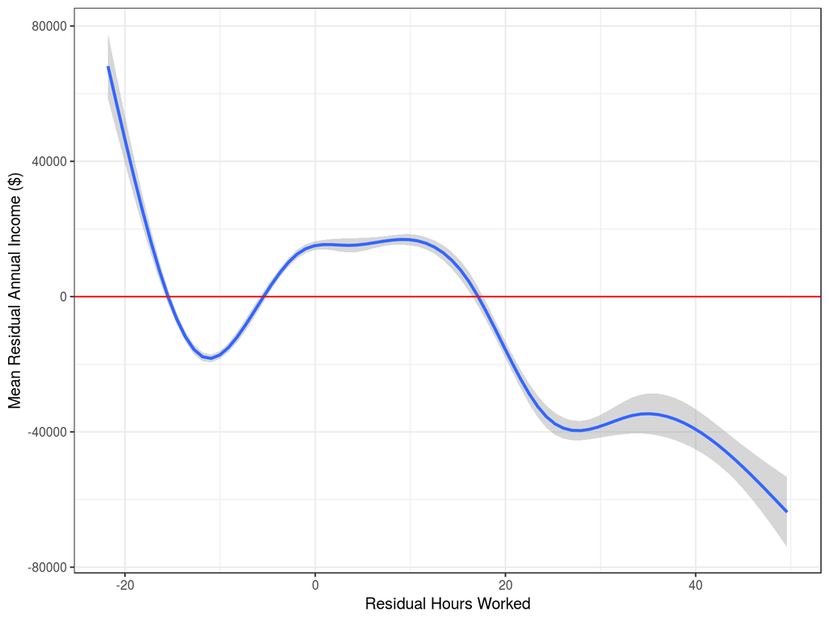

# Interpolation Bias

Another way of thinking about interpolation bias:

The point of conditioning is to compare different levels of “Treatment” for cases that are same on other attributes (so potential outcomes should be the same)

But when we condition using a regression and assume linearity, additivity, we compare cases against what they are estimated to be (which may depend on data-points that are very dissimilar)

# Potential Pitfalls

### (3) Extrapolation Bias:

- By forcing relationship between $Z$ (and for generality $Z_1 \ldots Z_k$) and $X$ to take some functional form (usually linear)…
- If cases with different levels of treatment are also different in terms of $Z$ (such that, e.g. there is no variation in treatment within strata), then causal inferences will depend on **extrapolation**
- This extrapolation is often heavily influenced by our mathematical assumptions rather than the underlying data/truth. (King and Zeng)
- Another name for this problem is a **lack of common support**… we don’t have otherwise similar cases across different kinds of treatment.

# Extrapolation Bias

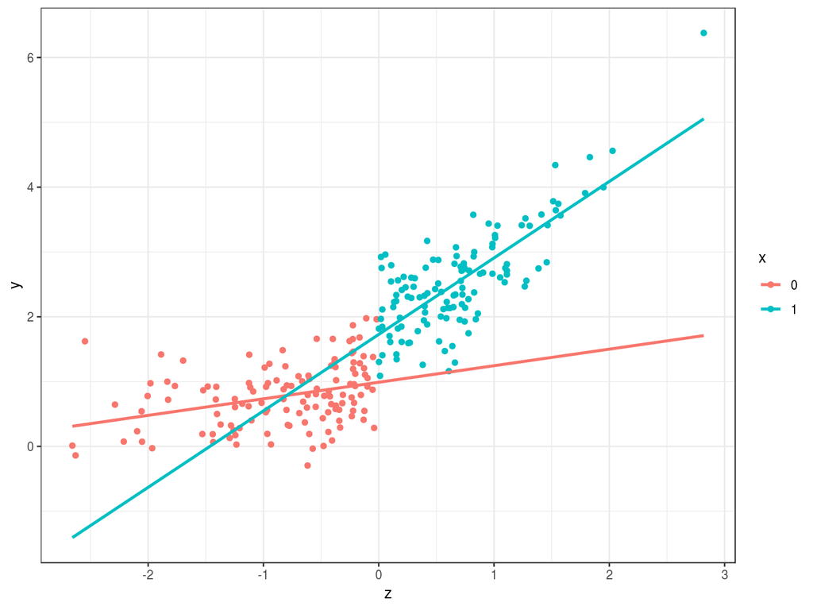

# Summary

Conditioning using regression can obtain an unbiased estimate for the effect of some cause when: